# Nouvelle offre Formation R Shiny

Josue Afouda

2023-01-06

# Partie 2 : Workflow et outils nécessaires pour le développement d’applications web Shiny destinées à la mise en production (Niveau Intermédiaire à Niveau Avancé)

## Prérequis : Avoir une bonne connaissance sur le développement de petites applications R Shiny (Preuve de Concept ou POC : *Proof Of Concept* en anglais). Celà concerne la partie 1 de la formation.

## Qu’entend t-on par logiciel/application en production ?

En matière de Développement logiciel (*Software Engineer*), on parle de “**production**” pour faire référence à la dernière étape du cycle de vie de développement d’un logiciel. C’est le moment où le logiciel est jugé prêt à être publié et distribué aux utilisateurs finaux. Dans un environnement de production, le logiciel doit fonctionner au mieux et être exempt de défauts. Cela contraste avec les premières étapes du cycle de vie de la construction d’applications telles que le développement et les tests. Pendant ces étapes (développement et tests), le ou les développeurs travaillent activement sur le logiciel afin de l’affiner.

EN gros, 2 critères principaux définissent un logiciel (ou une application) en production :

1. Utilisateurs : des personnes utilisent réellement ce logiciel dans leur travail quotidien et cette utilisation du logiciel a un impact réel sur leurs performances et celle de l’entreprise.
2. Ingénierie : l’application fonctionne exactement comme prévue par le ou les développeurs et elle est résistante aux changements ce qui suppose que le code est modulable, a subi plusieurs tests (avec succès) et est bien documenté ce qui va faciliter la reprise du travail pour l’écriture d’une nouvelle version par exemple.

L’objectif de cette deuxième partie de la formation est donc de vous apprendre à construire des applications web R Shiny qui respectent les 2 critères évoqués ci-dessus et qui peuvent donc passer en production. Vous apprendrez à passer d’une simple application prototype (POC) à une application déployable en production.

## Commencez sur de solides bases

La chose commune qu’on entend souvent est que Shiny est très bien pour construire des prototypes d’applications web. Et c’est vrai ! Mais Shiny est aussi utilisée en production dans plusieurs entreprises et est au coeur que la stratégie DATA dans plusieurs organisation. Quel que soit votre ambition pour votre application, vous devez toujours commencer sur de solides bases avec la mentalité d’un Software Engineer. Si vous ne le faites pas, vous aurez à réécrire tout le code de votre application afin qu’elle soit robuste et industrialisable.

Dans cette formation, vous apprendrez à construire des applications Shiny en tant que packages R en utilisant le package [golem](https://cran.r-project.org/web/packages/golem/index.html).

## Le travail en équipe

Dans les deux sous-sections ci-dessous, j’aborde le travail en équipe sous son angle purement technique. Toutefois, sachez que le développement logiciel n’est pas que technique. Il y a également l’aspect gestion (Management) du projet qui est très importante. Concernant cet aspect, chaque Entreprise a sa propre façon de faire et cela dépend souvent du Chef Projet. Pour ma part, j’adopte toujours la méthodologie agile pour mes projets de développement d’applications et je vous la conseille aussi. Il y a plusieurs ressources sur le net concernat la méthodologie agile. Il vous suffit de faire une petite recherche Google :). Mais en gros, l’image ci-dessous résume bien, selon moi, la philosophie qui sous-tend cette méthodologie :

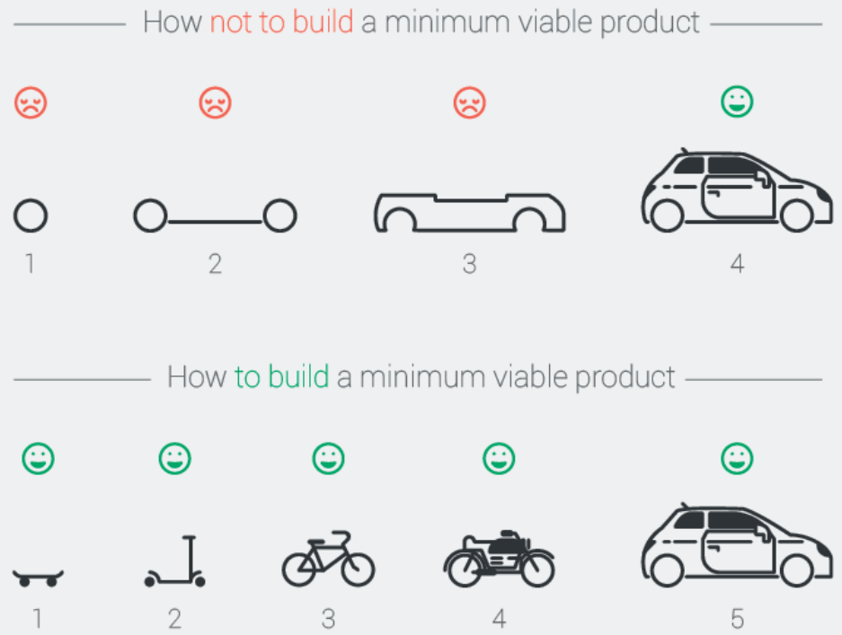

Cette image montre la manière efficace de construire un produit et ceci se résume en une phrase : *Faites-le fonctionner avant de l’optimiser*.

[Explication orale]

### Contrôle de version du code

Pour développer une application complexe prête à passer en production, vous avez fondamentalement besoin d’un outil qui suit les modifications apportées à votre code. [Git](https://git-scm.com/) est un système de contrôle de version open-source qui permet non seulement de suivre les changements apportés à votre code mais également de partarger ces changements avec les autres développeurs du projet. Git est souvent utilisé en combinaison avec [GitHub](https://github.com/) qui est un site web permettant d’héberger du code en ligne, de le partarger avec le monde et de soliciter des améliorations. Le duo Git/GitHub est le système de contrôle de version le plus populaire au monde et le plus utilisé par les développeurs R. Il n’est pas seulement utilisé en Software Engineering mais aussi en Data Science, Machine Learning, etc.

Vous apprendrez à utiliser le package golem qui est une boîte à outils permettant de packager une application Shiny prête pour la production. Ainsi votre application pourra être instalée comme n’importe quel package hébergé sur GitHub avec la commande :

```r
devtools::install_github("username/packagename")
```

Vous apprendrez aussi à déployer votre package dans le CRAN et elle pourra donc être installée par tout le monde avec la commande :

```r
install.packages("packagename")
```

### Modularisation du code R Shiny

Le code d’une application Shiny pour la production doit être divisé en de petits blocs appelés modules qui sont reliés les uns aux autres et qui permettent ainsi à chaque développeur de se concentrer sur un et un seul module à la fois.

Pour mieux comprendre ce concept, je vous invite à regarder cette vidéo : https://www.youtube.com/watch?v=LlS5VeivIJg. Même si dans cette vidéo, je parle de la modularisation du code en utilisant un code Python pour de l’apprentissage automatique, la compréhension est la même dans un contexte de développement d’applications web avec R Shiny.

[Pour exemples pratiques, voir pages 32-48 du livre et chapitre 19 du livre Masterning R Shiny].

## Construire une application web Shiny comme un package : Pourquoi ?

Il y 6 raisons principales au fait de construire une application web Shiny en tant que package :

1. **un package possède des métadonnées** : Les métadonnées (*metadata* en anglais) sont les informations nécessaires à tout logiciel en production telles que son nom, son utilité, sa version, les personnes à contacter en cas de problèmes, etc.
2. **un package gère lui-même toutes les dépendances nécessaires à son fonctionnement** : la gestion des dépendances est intrinsèque à la structure d’un package et en adoptant cette approche pour votre application web Shiny, vous éviterez d’inutiles maux de têtes e dérangements lorsque d’autres personnent l’installeront dans leurs machines.
3. **Un package est intrinsèquement divisé en modules** : Un packages est divisé en fonctions. Les fonctions sont groupées dans des fichiers .R (dossier R) <ui sont les modules. Ceci facilite la maintenance du packge si nécesszaaire, soit par vous-même ou soit par d’autres développeurs.
4. **Un package est documenté** : Chaque fonction du pakage est documentée. La documentation d’un package concerne à la fois les utilisateurs finaux de l’application et les futurs développeurs qui auront pour mission de la maintenir et de la mettre à jour. Ce qui est intéressant, c’est que la documentation de votre package est compilée automatiquement grâce au package [roxygen2][https://cran.r-project.org/web/packages/roxygen2/index.html]. De plus, vous pouvez utiliser le package pkgdown pour construire un beau site web pour votre package et ceci en une seule commande :

```r
pkgdown::build_site()
```

5. **un package est (évidemment) testé** : tout d’abord, il faut savoir que rien ne va en production sans être testé. Mais comment tester une application web R Shiny ? Etant donné que dans l’écosystème de R, les frameworks ([testthat](https://cran.r-project.org/web/packages/testthat/index.html)) pour le test de package sont très bien documentés et faciles à implémenter. Vous n’aurez ucun mal à les utiliser pour tester votre application web R Shiny si vous la construisez comme un package.
6. **un package est intrinsèquement facile à partarger** : si vous construisez votre application web comme un package, vous pouvez la partarger facilement :
- en tant que fichier *tar.gz* ;
- sur internet via votre compte GitHub afin que tout le monde puisse l’installer en utilisant la commande :

```r
devtools::install_github("username/packagename")
```

- sur internet via le CRAN afin que tout le mond epuisse l’installer via la commande :

```r
install.packages("packagename")
```